# A tour of the Scientific Oceanographic Python stack

```python
HTML(ids)
```

ocefpaf

ocefpaf

ocefpaf@gmail.com

### Before we begin some FAQ

- How to install Python?
- Should I use a distribution?
- Python 2 or 3?
- Why we cannot have a single installer like MatlabTM!?

One answer to all questions is to use the Anaconda Python distribution:

```
url=http://bit.ly/miniconda

wget $url -O miniconda.sh
bash miniconda.sh -b
export PATH=$HOME/miniconda/bin:$PATH
conda update --yes --all
```

```
url=http://bit.ly/conda-env

wget $url -O environment.yml
conda env create environment.yml
```

# NumPy

http://www.numpy.org/

See also:

- http://www.labri.fr/perso/nrougier/teaching/numpy.100/
- http://mathesaurus.sourceforge.net/matlab-numpy.html

Reading some data

```python
!head -n 5 ./data/dados_pirata.csv
```

```
,datahora,t_1,t_10,t_100,t_120,t_13,t_140,t_180,t_20,t_300,t_40,t_5,t_500,t_60,t_80
0,2005-08-24 12:00:00+00:00,25.19,-99999.0,25.2,24.89,-99999.0,23.79,20.6,25.17,12.46,25.17,-99999.0,6.82,25.19,25.19
1,2005-08-25 12:00:00+00:00,25.19,-99999.0,25.17,24.72,-99999.0,23.61,20.31,25.18,12.27,25.18,-99999.0,6.85,25.21,25.18
2,2005-08-26 12:00:00+00:00,25.26,-99999.0,25.13,24.74,-99999.0,23.63,20.43,25.24,12.36,25.22,-99999.0,6.87,25.2,25.16
3,2005-08-27 12:00:00+00:00,25.23,-99999.0,25.04,24.77,-99999.0,23.74,20.1,25.19,12.23,25.19,-99999.0,6.86,25.14,25.08
```

We need to skip the header and the date-time columns

```python
import numpy as np

data = np.loadtxt("./data/dados_pirata.csv",
                  skiprows=1,
                  usecols=range(2, 16),
                  delimiter=',')

data[data == -99999.] = np.NaN

data.shape, data.dtype
```

```
((3653, 14), dtype('float64'))
```

But the depth information was in header!

We need to type that in...

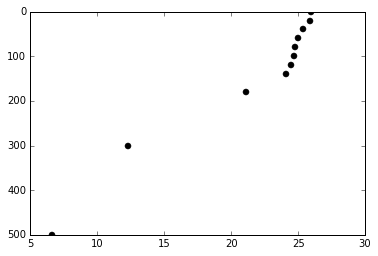

```python
%matplotlib inline
import matplotlib.pyplot as plt

z = [1, 10, 100, 120, 13, 140, 180, 20,
     300, 40,5, 500, 60, 80]

fig, ax = plt.subplots()
# Points because z was not ordered.
ax.plot(data[42, :], z, 'ko')
ax.invert_yaxis()
```

# Pandas: can we do better than NumPy arrays?

http://pandas.pydata.org/

Note that almost everything we did before, and some more, is now done at the loading time

```python
import pandas as pd

df = pd.read_csv('./data/dados_pirata.csv',
                 index_col='datahora',
                 parse_dates=True,
                 na_values=-99999)
df.drop('Unnamed: 0', axis=1, inplace=True)
df.columns = ['{0:0>3}'.format(col.split('_')[1]) for
              col in df.columns]
df.sort(axis=1, inplace=True)

df.head(3)
```

| datahora | 001 | 005 | 010 | 013 | 020 | 040 | 060 | 080 | 100 | 120 | 140 | 180 | 300 | 500 |
| --- | --- | --- | --- | --- | --- | --- | --- | --- | --- | --- | --- | --- | --- | --- |
| 2005-08-24 12:00:00 | 25.19 | NaN | NaN | NaN | 25.17 | 25.17 | 25.19 | 25.19 | 25.20 | 24.89 | 23.79 | 20.60 | 12.46 | 6.82 |
| 2005-08-25 12:00:00 | 25.19 | NaN | NaN | NaN | 25.18 | 25.18 | 25.21 | 25.18 | 25.17 | 24.72 | 23.61 | 20.31 | 12.27 | 6.85 |
| 2005-08-26 12:00:00 | 25.26 | NaN | NaN | NaN | 25.24 | 25.22 | 25.20 | 25.16 | 25.13 | 24.74 | 23.63 | 20.43 | 12.36 | 6.87 |

Pandas behave like masked-arrays, but with some extra convenience functions beyond `nan{min,max,mean,etc}`

```python
df.dropna(how='all', axis=1, inplace=True)

df.head(3)
```

| datahora | 001 | 020 | 040 | 060 | 080 | 100 | 120 | 140 | 180 | 300 | 500 |
| --- | --- | --- | --- | --- | --- | --- | --- | --- | --- | --- | --- |
| 2005-08-24 12:00:00 | 25.19 | 25.17 | 25.17 | 25.19 | 25.19 | 25.20 | 24.89 | 23.79 | 20.60 | 12.46 | 6.82 |
| 2005-08-25 12:00:00 | 25.19 | 25.18 | 25.18 | 25.21 | 25.18 | 25.17 | 24.72 | 23.61 | 20.31 | 12.27 | 6.85 |
| 2005-08-26 12:00:00 | 25.26 | 25.24 | 25.22 | 25.20 | 25.16 | 25.13 | 24.74 | 23.63 | 20.43 | 12.36 | 6.87 |

Quick way to explore the data

```python
desc = df.describe()
desc
```

|  | 001 | 020 | 040 | 060 | 080 | 100 | 120 | 140 | 180 | 300 | 500 |
| --- | --- | --- | --- | --- | --- | --- | --- | --- | --- | --- | --- |
| count | 3206.000000 | 2949.000000 | 3408.000000 | 3408.000000 | 3161.000000 | 3407.000000 | 3405.000000 | 3405.000000 | 3405.000000 | 3405.000000 | 3405.000000 |
| mean | 26.903054 | 26.856673 | 26.746086 | 26.283706 | 25.486109 | 24.681382 | 23.947416 | 23.076496 | 20.080417 | 12.359806 | 6.675656 |
| std | 1.030174 | 0.999788 | 0.992836 | 0.840345 | 0.523529 | 0.500878 | 0.607452 | 0.755077 | 1.081181 | 0.461918 | 0.266193 |
| min | 24.710000 | 24.820000 | 24.630000 | 24.550000 | 23.950000 | 22.850000 | 21.450000 | 20.110000 | 17.210000 | 10.930000 | 5.620000 |
| 25% | 26.020000 | 25.970000 | 25.880000 | 25.590000 | 25.120000 | 24.350000 | 23.550000 | 22.590000 | 19.260000 | 12.050000 | 6.500000 |
| 50% | 26.940000 | 26.900000 | 26.820000 | 26.210000 | 25.430000 | 24.660000 | 23.920000 | 23.090000 | 20.100000 | 12.370000 | 6.700000 |
| 75% | 27.750000 | 27.720000 | 27.580000 | 26.960000 | 25.800000 | 24.990000 | 24.350000 | 23.620000 | 20.880000 | 12.670000 | 6.840000 |
| max | 29.090000 | 28.840000 | 28.790000 | 28.580000 | 27.080000 | 26.450000 | 25.580000 | 25.180000 | 23.210000 | 13.630000 | 7.790000 |

High level code! No need for comments to describe what is being computed below:

```python
desc.ix['std'] ** 2
```

```
001    1.061258
020    0.999577
040    0.985722
060    0.706179
080    0.274083
100    0.250879
120    0.368998
140    0.570141
180    1.168953
300    0.213368
500    0.070859
Name: std, dtype: float64
```

What levels are we plotting?

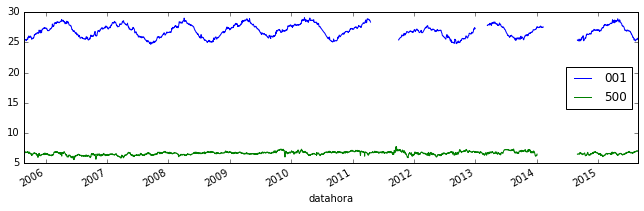

```python
ax = df[['001', '500']].plot(figsize=(11, 3))
```

More convenience functions:

- interpolate

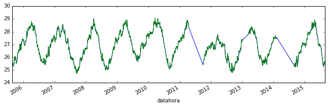

```python
df['001'].interpolate().plot(figsize=(11, 3))
ax = df['001'].plot()
```

Full control of the interpolation

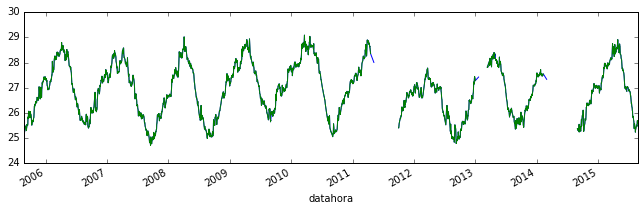

```python
kw = dict(method='time', limit=20)
df['001'].interpolate(**kw).plot(figsize=(11, 3))
ax = df['001'].plot()
```

Pandas loves time-series

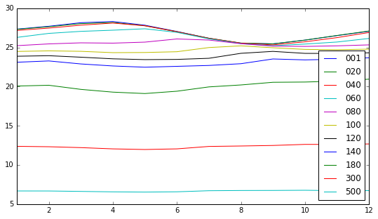

```python
key = lambda x: x.month

grouped = df.groupby(key)

monthly = grouped.mean()

fig, ax = plt.subplots(figsize=(9, 5))

ax = monthly.plot(ax=ax)
```

## Pandas has a few siblings:

- geopandas
- ctd
- xray

GeoPandas read GeoJSONs, Shapefiles, etc as pandas DataFrames

http://geopandas.org/

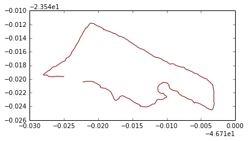

```python
import rasterio
import geopandas as gpd

fname = "./data/2013-04-29-Running.geojson"

df = gpd.read_file(fname)
ax = df.plot()
```

The geometries are essentially shapely objects

```python
shape = df['geometry'][0]

msg = """
Length is {} km.

The center is locate at {!r}.

The track bounds are {}.
""".format
print(msg(shape.length * 111, shape.centroid.xy,
          shape.bounds))
```

```
Length is 7.2781139639 km.

The center is locate at (array('d', [-46.724456529983655]), array('d', [-23.55928803359001])).

The track bounds are (-46.73799172975123, -23.564499272033572, -46.71305129304528, -23.551835222169757).
```

ptyhon-ctd loads `ctd`, `xbt`, and many more ocean profilers directly into pandas

https://pypi.python.org/pypi/ctd

```python
from ctd import DataFrame

cast = DataFrame.from_cnv('./data/CTD_001.cnv.gz', compression='gzip')

cast.head()
```

| Pressure [dbar] | scan | timeS | t090C | t190C | c0S/m | c1S/m | sbeox0V | par | spar | ph | ... | longitude | pumps | pla | sbeox0PS | sbeox0Mm/Kg | dz/dtM | accM | flSP | xmiss | flag |
| --- | --- | --- | --- | --- | --- | --- | --- | --- | --- | --- | --- | --- | --- | --- | --- | --- | --- | --- | --- | --- | --- |
| 2.810 | 1 | 0.000 | 24.2158 | 24.2132 | 5.527058 | 5.526362 | 2.8107 | 1.000000e-12 | 11.761 | -2.332 | ... | -47.452167 | True | 24.221 | 71.49588 | 147.595 | 0.000 | 0.00 | 0.11111 | 96.8657 | False |
| 2.846 | 2 | 0.042 | 24.2158 | 24.2132 | 5.527065 | 5.526352 | 2.8120 | 1.000000e-12 | 13.721 | -2.336 | ... | -47.452167 | True | 24.221 | 71.53789 | 147.682 | 0.878 | 21.08 | 0.10867 | 96.8657 | False |
| 2.810 | 3 | 0.083 | 24.2156 | 24.2131 | 5.527060 | 5.526333 | 2.8120 | 1.000000e-12 | 11.761 | -2.336 | ... | -47.452167 | True | 24.221 | 71.53759 | 147.682 | -0.878 | -42.16 | 0.10623 | 96.8657 | False |
| 2.744 | 4 | 0.125 | 24.2156 | 24.2132 | 5.527091 | 5.526339 | 2.8120 | 1.000000e-12 | 13.721 | -2.336 | ... | -47.452167 | True | 24.221 | 71.53702 | 147.680 | -1.581 | -16.87 | 0.10745 | 96.8657 | False |
| 2.707 | 5 | 0.167 | 24.2158 | 24.2134 | 5.527052 | 5.526343 | 2.8132 | 1.000000e-12 | 13.721 | -2.332 | ... | -47.452167 | True | 24.221 | 71.57837 | 147.766 | -0.878 | 16.87 | 0.11111 | 96.9189 | False |

5 rows × 30 columns

The augmented DataFrame has some extra methods to process CTD data

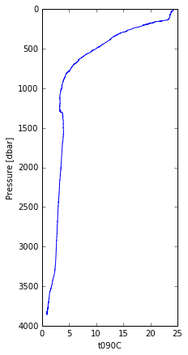

```python
downcast, upcast = cast['t090C'].split()
fig, ax = downcast.plot(figsize=(3, 7))
```

xray: `netCDF4` + `pandas` for >2D tables

http://xray.readthedocs.org/en/stable/

```python
import xray

url = ('http://geoport.whoi.edu/thredds/dodsC/clay/usgs/'
       'users/jcwarner/Projects/Sandy/triple_nest/'
       '00_dir_NYB05.ncml')

ds = xray.open_dataset(url)
ds
```

```
<xray.Dataset>
Dimensions:                 (NST: 6, Nbed: 1, eta_psi: 106, eta_rho: 107, eta_u: 107, eta_v: 106, ocean_time: 201, s_rho: 16, s_w: 17, tracer: 8, xi_psi: 344, xi_rho: 345, xi_u: 344, xi_v: 345)
Coordinates:
  * s_rho                   (s_rho) float64 -0.9688 -0.9062 -0.8438 -0.7812 ...
  * s_w                     (s_w) float64 -1.0 -0.9375 -0.875 -0.8125 -0.75 ...
    lon_rho                 (eta_rho, xi_rho) float64 ...
    lat_rho                 (eta_rho, xi_rho) float64 ...
    lon_u                   (eta_u, xi_u) float64 ...
    lat_u                   (eta_u, xi_u) float64 ...
    lon_v                   (eta_v, xi_v) float64 ...
    lat_v                   (eta_v, xi_v) float64 ...
    lon_psi                 (eta_psi, xi_psi) float64 ...
    lat_psi                 (eta_psi, xi_psi) float64 ...
  * ocean_time              (ocean_time) datetime64[ns] 2012-10-25 ...
  * NST                     (NST) int64 0 1 2 3 4 5
  * Nbed                    (Nbed) int64 0
  * eta_psi                 (eta_psi) int64 0 1 2 3 4 5 6 7 8 9 10 11 12 13 ...
  * eta_rho                 (eta_rho) int64 0 1 2 3 4 5 6 7 8 9 10 11 12 13 ...
  * eta_u                   (eta_u) int64 0 1 2 3 4 5 6 7 8 9 10 11 12 13 14 ...
  * eta_v                   (eta_v) int64 0 1 2 3 4 5 6 7 8 9 10 11 12 13 14 ...
  * tracer                  (tracer) int64 0 1 2 3 4 5 6 7
  * xi_psi                  (xi_psi) int64 0 1 2 3 4 5 6 7 8 9 10 11 12 13 ...
  * xi_rho                  (xi_rho) int64 0 1 2 3 4 5 6 7 8 9 10 11 12 13 ...
  * xi_u                    (xi_u) int64 0 1 2 3 4 5 6 7 8 9 10 11 12 13 14 ...
  * xi_v                    (xi_v) int64 0 1 2 3 4 5 6 7 8 9 10 11 12 13 14 ...
Data variables:
    ntimes                  int32 ...
    ndtfast                 int32 ...
    dt                      float64 ...
    dtfast                  float64 ...
    dstart                  datetime64[ns] ...
    nHIS                    int32 ...
    ndefHIS                 int32 ...
    nRST                    int32 ...
    Falpha                  float64 ...
    Fbeta                   float64 ...
    Fgamma                  float64 ...
    nl_tnu2                 (tracer) float64 ...
    nl_visc2                float64 ...
    LuvSponge               int32 ...
```

[output cut: 188 more lines]

```
    ana_file: ROMS/Functionals/ana_btflux.h, ROMS/Functionals/ana_fsobc.h, ROMS/Functionals/ana_m2obc.h, ROMS/Functionals/ana_nudgcoef.h, ROMS/Functionals/ana_srflux.h, ROMS/Functionals/ana_stflux.h
    CPP_options: FIREISLAND, ANA_BPFLUX, ANA_BSFLUX, ANA_BTFLUX, ANA_FSOBC, ANA_M2OBC, ANA_NUDGCOEF, ANA_SPFLUX, ANA_SRFLUX, ASSUMED_SHAPE, ATM_PRESS, BEDLOAD_SOULSBY, BULK_FLUXES, CHARNOK, CRAIG_BANNER, COARE_TAYLOR_YELLAND, CURVGRID, DJ_GRADPS, DOUBLE_PRECISION, EMINUSP, GLS_MIXING, KANTHA_CLAYSON…
    cdm_data_type: Grid
    publisher_email: jcwarner@usgs.gov
    publisher_url: http://woodshole.er.usgs.gov/staffpages/jwarner/
    publisher_name: John Warner
    license: The data may be used and redistributed for free but is not intended for legal use, since it may contain inaccuracies. Neither the data Contributor, nor the United States Government, nor any of their employees or contractors, makes any warranty, express or implied, including warranties o…
    creator_email: jcwarner@usgs.gov
    creator_url: http://woodshole.er.usgs.gov/staffpages/jwarner/
    creator_name: John Warner
    summary: Simulation of hydrodynamics, waves, bottom stress and sediment transport during Hurricane Sandy. These results are from the 700m finest resolutionnest of a three-level nested simulation.
    project: CMG_Portal,Sandy_Portal
    references: http://woodshole.er.usgs.gov/operations/modeling/COAWST/,doi:10.1016/j.cageo.2008.02.012
    id: USGS_COAWST_Sandy_NYB05_sim6
    naming_authority: gov.usgs.cmg
```

Slice the variables using the `var name` (like `netCDF4`)

```python
temp = ds['temp']
temp
```

```
<xray.DataArray 'temp' (ocean_time: 201, s_rho: 16, eta_rho: 107, xi_rho: 345)>
[118718640 values with dtype=float64]
Coordinates:
    lon_rho     (eta_rho, xi_rho) float64 ...
    lat_rho     (eta_rho, xi_rho) float64 ...
  * ocean_time  (ocean_time) datetime64[ns] 2012-10-25 2012-10-25T01:00:00 ...
  * xi_rho      (xi_rho) int64 0 1 2 3 4 5 6 7 8 9 10 11 12 13 14 15 16 17 ...
  * s_rho       (s_rho) float64 -0.9688 -0.9062 -0.8438 -0.7812 -0.7188 ...
  * eta_rho     (eta_rho) int64 0 1 2 3 4 5 6 7 8 9 10 11 12 13 14 15 16 17 ...
Attributes:
    long_name: potential temperature
    units: Celsius
    time: ocean_time
    field: temperature, scalar, series
    standard_name: sea_water_potential_temperature
    grid: grid
    content_coverage_type: modelResult
    location: face
```

Use high-level dates slice (like pandas)

```python
temp.sel(ocean_time='2012-10-25')
```

```
<xray.DataArray 'temp' (ocean_time: 24, s_rho: 16, eta_rho: 107, xi_rho: 345)>
[14175360 values with dtype=float64]
Coordinates:
    lon_rho     (eta_rho, xi_rho) float64 ...
    lat_rho     (eta_rho, xi_rho) float64 ...
  * ocean_time  (ocean_time) datetime64[ns] 2012-10-25 2012-10-25T01:00:00 ...
  * xi_rho      (xi_rho) int64 0 1 2 3 4 5 6 7 8 9 10 11 12 13 14 15 16 17 ...
  * s_rho       (s_rho) float64 -0.9688 -0.9062 -0.8438 -0.7812 -0.7188 ...
  * eta_rho     (eta_rho) int64 0 1 2 3 4 5 6 7 8 9 10 11 12 13 14 15 16 17 ...
Attributes:
    long_name: potential temperature
    units: Celsius
    time: ocean_time
    field: temperature, scalar, series
    standard_name: sea_water_potential_temperature
    grid: grid
    content_coverage_type: modelResult
    location: face
```

All pandas time-series goodies are present

```
temp.resample('1M', 'ocean_time')
```

You can even slice using integers and named the axis

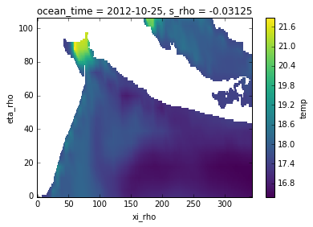

```python
t = temp.isel(s_rho=-1, ocean_time=0)

cs = t.plot()
```

# dask: execute"bigger than memory" operations

http://dask.pydata.org/en/latest/

https://jakevdp.github.io/blog/2015/08/14/out-of-core-dataframes-in-python/

The following lines do not download the data

```python
from netCDF4 import Dataset

nc = Dataset(url)

t = nc['temp']
s = nc['salt']

t.shape, s.shape
```

```
((201, 16, 107, 345), (201, 16, 107, 345))
```

```python
import dask.array as da

chunks = (1, 16, 107, 345)

t = da.from_array(t, chunks=chunks)
s = da.from_array(s, chunks=chunks)

t
```

```
dask.array<from-ar..., shape=(201, 16, 107, 345), dtype=float32, chunksize=(1, 16, 107, 345)>
```

Note that the result is a dask element wise object

```python
(s + t) * 2
```

```
dask.array<elemwis..., shape=(201, 16, 107, 345), dtype=float32, chunksize=(1, 16, 107, 345)>
```

You need to manually trigger the computations to load the data. Note that some operations, like plotting, will load the data automatically:

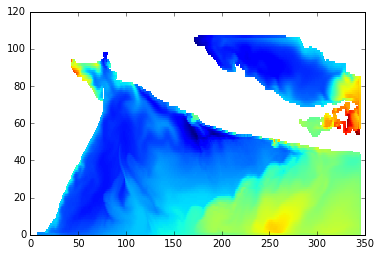

```python
import gsw
import seawater as sw
import numpy.ma as ma

sigma0 = gsw.sigma0(s[-1, :, :, :], t[-1, :, :, :])
cs = plt.pcolormesh(ma.masked_equal(sigma0, -1000))
```

# cartopy: maps!

http://scitools.org.uk/cartopy/

The first python library to actually solve the dateline problem

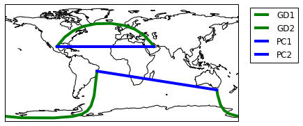

```python
import matplotlib.pyplot as plt
import cartopy.crs as ccrs
projection = ccrs.PlateCarree()
ax = plt.axes(projection=projection)
ax.coastlines(); ax.set_global()

kw = dict(lw=4, color='g', transform=ccrs.Geodetic())
l0 = plt.plot([-100, 50], [25, 25], label='GD1', **kw)
l1 = plt.plot([-38, 147], [-13, -42], label='GD2', **kw)

kw = dict(linewidth=4, color='b', transform=projection)
l2 = plt.plot([-100, 50], [25, 25], label='PC1', **kw)
l3 = plt.plot([-38, 147], [-13, -42], label='PC2', **kw)

leg = ax.legend(loc=(1.05, 0.5))
```

When creating a lot of maps it is convenient to wrap them in a plotting function

```python
from oceans import cm
import matplotlib.pyplot as plt

import cartopy.crs as ccrs
from cartopy.mpl.gridliner import (LONGITUDE_FORMATTER,
                                   LATITUDE_FORMATTER)

def make_map(projection=ccrs.PlateCarree()):
    subplot_kw = dict(projection=projection)
    fig, ax = plt.subplots(figsize=(9, 13),
                           subplot_kw=subplot_kw)
    gl = ax.gridlines(draw_labels=True)
    gl.xlabels_top = gl.ylabels_right = False
    gl.xformatter = LONGITUDE_FORMATTER
    gl.yformatter = LATITUDE_FORMATTER
    return fig, ax
```

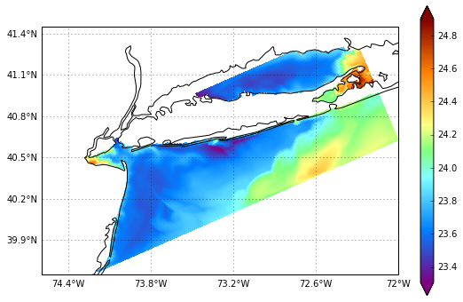

```python
lon = nc['lon_rho'][:]
lat = nc['lat_rho'][:]

fig, ax = make_map()
ax.set_extent([lon.min(), lon.max(), lat.min(), lat.max()])
ax.coastlines('10m')
s0 = ma.masked_equal(sigma0, -1000)
cs = ax.pcolormesh(lon, lat, s0, cmap=cm.avhrr)
cbar = fig.colorbar(cs, shrink=0.45, extend='both')
```

# iris

http://scitools.org.uk/iris/docs/latest/index.html

Iris is an interpretation of the [CF-Conventions](http://cfconventions.org/). The main object is the `cube`:

```python
import iris

cubes = iris.load_raw(url)
print(cubes)
```

```
0: sediment concentration used in uniform initial conditions / (kilogram meter-3) (-- : 6)
1: sediment surface layer erosing rate / (kilogram meter-2 second-1) (-- : 6)
2: maximum wind and current, bottom v-wave stress / (newton meter-2) (time: 201; -- : 107; -- : 345)
3: erosion or deposition / (meter)     (time: 201; -- : 107; -- : 345)
4: sediment critical shear for deposition / (Newton meter-2) (-- : 6)
5: sediment critical shear for erosion / (Newton meter-2) (-- : 6)
6: v-Stokes drift velocity / (meter second-1) (time: 201; ocean_s_coordinate_g1: 16; -- : 106; -- : 345)
7: sediment median grain density / (kilogram meter3) (time: 201; -- : 107; -- : 345)
8: current-induced, bottom v-momentum stress / (newton meter-2) (time: 201; -- : 107; -- : 345)
9: wind-induced, bottom v-momentum stress / (newton meter-2) (time: 201; -- : 107; -- : 345)
10: sea_surface_wave_significant_height / (meter) (time: 201; -- : 107; -- : 345)
11: bed load flux of sand in V-direction, size class 03 / (kilogram meter-1 s-1) (time: 201; -- : 106; -- : 345)
12: bed load flux of sand in V-direction, size class 02 / (kilogram meter-1 s-1) (time: 201; -- : 106; -- : 345)
13: bed load flux of sand in V-direction, size class 01 / (kilogram meter-1 s-1) (time: 201; -- : 106; -- : 345)
14: biodiffusivity at bottom of each layer / (meter2 second-1) (time: 201; -- : 1; -- : 107; -- : 345)
```

[output cut: 83 more lines]

We can take advantage of the CF conventions to access variables by its `standard_name`

```python
temp = cubes.extract_strict('sea_water_potential_temperature')
print(temp)
```

```
sea_water_potential_temperature               (time: 201; ocean_s_coordinate_g1: 16; -- : 107; -- : 345)
     Dimension coordinates:
          time                                             x                           -        -         -
          ocean_s_coordinate_g1                            -                           x        -         -
     Auxiliary coordinates:
          free-surface                                     x                           -        x         x
          S-coordinate stretching curves at RHO-points     -                           x        -         -
          bathymetry at RHO-points                         -                           -        x         x
          latitude                                         -                           -        x         x
          longitude                                        -                           -        x         x
     Derived coordinates:
          sea_surface_height_above_reference_ellipsoid     x                           x        x         x
     Scalar coordinates:
          S-coordinate parameter, critical depth: 2.0 meter
     Attributes:
          CPP_options: FIREISLAND, ANA_BPFLUX, ANA_BSFLUX, ANA_BTFLUX, ANA_FSOBC, ANA_M2OBC, ANA_NUDGCOEF,...
          Conventions: CF-1.6, SGRID-0.1, ACDD-1.3
          NLM_LBC:
EDGE:         WEST   SOUTH  EAST   NORTH
zeta:         Nes    Nes  ...
          ana_file: ROMS/Functionals/ana_btflux.h, ROMS/Functionals/ana_fsobc.h, ROMS/Functionals/ana_m2obc.h,...
          cdm_data_type: Grid
          clm_file_01: ../forcings/merged_coawst_clm_10Sep_29Dec2012.nc
          code_dir: /raid3/jcwarner/Projects/Sandy/sim6
          compiler_command: /usr/local/mpi/bin/mpif90
          compiler_flags:  -fastsse -Mipa=fast -tp k8-64 -Mfree
          compiler_system: pgi
          content_coverage_type: modelResult
          cpu: x86_64
          creator_email: jcwarner@usgs.gov
          creator_name: John Warner
          creator_url: http://woodshole.er.usgs.gov/staffpages/jwarner/
          field: temperature, scalar, series
          file: Output/ocean_NYB05_his_0016.nc
          format: netCDF-3 64bit offset file
          frc_file_01: ../forcings/roms_namnarr_2030Oct2012.nc, ../forcings/roms_namnarr_30Oc...
          grd_file: ../grids/NYB_700m_05.nc
          grid: grid
          header_dir: /raid3/jcwarner/Projects/Sandy/sim6/Projects/FireIsland
          header_file: fireisland.h
          his_base: Output/ocean_NYB05_his
          history: ROMS/TOMS, Version 3.7, Tuesday - June 2, 2015 - 10:15:23 PM
          id: USGS_COAWST_Sandy_NYB05_sim6
          ini_file: Output/ocean_NYB05_his_0009.nc
          license: The data may be used and redistributed for free but is not intended for...
          location: face
          naming_authority: gov.usgs.cmg
          os: Linux
          project: CMG_Portal,Sandy_Portal
          publisher_email: jcwarner@usgs.gov
          publisher_name: John Warner
          publisher_url: http://woodshole.er.usgs.gov/staffpages/jwarner/
          references: http://woodshole.er.usgs.gov/operations/modeling/COAWST/,doi:10.1016/j...
          rst_file: Output/ocean_NYB05_rst.nc
          script_file:
          summary: Simulation of hydrodynamics, waves, bottom stress and sediment transport...
          svn_rev: exported
          svn_url: https:://myroms.org/svn/src
          tiling: 008x005
          time: ocean_time
          title: USGS-CMG-COAWST Model: Hurricane Sandy, NYB05 700m Nest
          type: ROMS/TOMS history file
```

Like `xray` we have both high and low level slicing (Although the high level slicing in `iris` is too sophisticated for my taste ;-)

```python
t = temp[-1, -1, ...]

print(t)  # The metadata is always propagated.
```

```
sea_water_potential_temperature             (-- : 107; -- : 345)
     Auxiliary coordinates:
          bathymetry at RHO-points                         x         x
          free-surface                                     x         x
          latitude                                         x         x
          longitude                                        x         x
     Derived coordinates:
          sea_surface_height_above_reference_ellipsoid     x         x
     Scalar coordinates:
          S-coordinate parameter, critical depth: 2.0 meter
          S-coordinate stretching curves at RHO-points: -0.00225488671278
          ocean_s_coordinate_g1: -0.03125
          time: 2012-11-02 08:00:00.000006
     Attributes:
          CPP_options: FIREISLAND, ANA_BPFLUX, ANA_BSFLUX, ANA_BTFLUX, ANA_FSOBC, ANA_M2OBC, ANA_NUDGCOEF,...
          Conventions: CF-1.6, SGRID-0.1, ACDD-1.3
          NLM_LBC:
EDGE:         WEST   SOUTH  EAST   NORTH
zeta:         Nes    Nes  ...
          ana_file: ROMS/Functionals/ana_btflux.h, ROMS/Functionals/ana_fsobc.h, ROMS/Functionals/ana_m2obc.h,...
          cdm_data_type: Grid
          clm_file_01: ../forcings/merged_coawst_clm_10Sep_29Dec2012.nc
          code_dir: /raid3/jcwarner/Projects/Sandy/sim6
          compiler_command: /usr/local/mpi/bin/mpif90
          compiler_flags:  -fastsse -Mipa=fast -tp k8-64 -Mfree
          compiler_system: pgi
          content_coverage_type: modelResult
          cpu: x86_64
          creator_email: jcwarner@usgs.gov
          creator_name: John Warner
          creator_url: http://woodshole.er.usgs.gov/staffpages/jwarner/
          field: temperature, scalar, series
          file: Output/ocean_NYB05_his_0016.nc
          format: netCDF-3 64bit offset file
          frc_file_01: ../forcings/roms_namnarr_2030Oct2012.nc, ../forcings/roms_namnarr_30Oc...
          grd_file: ../grids/NYB_700m_05.nc
          grid: grid
          header_dir: /raid3/jcwarner/Projects/Sandy/sim6/Projects/FireIsland
          header_file: fireisland.h
          his_base: Output/ocean_NYB05_his
          history: ROMS/TOMS, Version 3.7, Tuesday - June 2, 2015 - 10:15:23 PM
          id: USGS_COAWST_Sandy_NYB05_sim6
          ini_file: Output/ocean_NYB05_his_0009.nc
          license: The data may be used and redistributed for free but is not intended for...
          location: face
          naming_authority: gov.usgs.cmg
          os: Linux
          project: CMG_Portal,Sandy_Portal
          publisher_email: jcwarner@usgs.gov
          publisher_name: John Warner
          publisher_url: http://woodshole.er.usgs.gov/staffpages/jwarner/
          references: http://woodshole.er.usgs.gov/operations/modeling/COAWST/,doi:10.1016/j...
          rst_file: Output/ocean_NYB05_rst.nc
          script_file:
          summary: Simulation of hydrodynamics, waves, bottom stress and sediment transport...
          svn_rev: exported
          svn_url: https:://myroms.org/svn/src
          tiling: 008x005
          time: ocean_time
          title: USGS-CMG-COAWST Model: Hurricane Sandy, NYB05 700m Nest
          type: ROMS/TOMS history file
```

There are even some quick plotting routines to explore the data. Note the free colorbar, units label, and title:

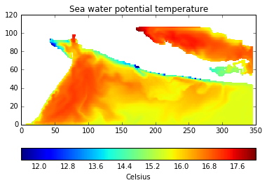

```python
import iris.quickplot as qplt

cs = qplt.pcolormesh(t)
```

# Some very "oceanographic" libraries

- [odvc](https://raw.githubusercontent.com/ioos/odvc/master/notebooks/ocean_sigma_coordinate-FVCOM.ipynb)
- [pyoos](http://ioos.github.io/system-test/)
- [pyugrid](https://ocefpaf.github.io/python4oceanographers/blog/2015/07/20/pyugrid/)
- [pysgrid](http://nbviewer.ipython.org/urls/raw.githubusercontent.com/sgrid/pysgrid/master/pysgrid/notebook_examples/hudson_shelf_valley.ipynb)
- [ciso](http://nbviewer.ipython.org/gist/ocefpaf/ee14af5220bc3512131f)
- [utide](https://ocefpaf.github.io/python4oceanographers/blog/2015/05/18/utide_ellipse/)

# Some not so "oceanographic" but very useful

- [scipy](http://www.scipy.org/)
- [scikit-learn](http://scikit-learn.org/stable/)
- [scikit-image](http://scikit-image.org/)
- [statsmodels](http://statsmodels.sourceforge.net/)
- [bokeh](http://bokeh.pydata.org/en/latest/)
- [numba](http://numba.pydata.org/)
- [cython](http://cython.org/)
- [sympy](http://www.sympy.org/en/index.html)

# Extra resources

- Blog: http://ocefpaf.github.io/python4oceanographers/
- Installation: https://github.com/ioos/conda-recipes/wiki/Setting-up-the-IOOS-Python-environment
- Software list: https://ocefpaf.github.io/seapy/
- And the [Jupyter/IPython notebook](http://jupyter-notebook-beginner-guide.readthedocs.org/en/latest/)

# Extra slides

## Using python as a glue language

Calling matlab

(See matlab_kernel for full matlab)

```python
try:
    %load_ext oct2py.ipython
    octave = True
except AttributeError as e:
    octave = False
    print(e)
    print("You cannot run the next 2 cells with the octave example :-(")
```

```python
%%file fahr_to_kelvin.m

function ktemp = fahr_to_kelvin(ftemp)
    ktemp = ((ftemp - 32) * (5/9)) + 273.15;
end
```

```
Overwriting fahr_to_kelvin.m
```

```python
if octave:
    %octave fahr_to_kelvin(32)
```

```
ans =  273.15
```

Calling Fortran

```python
%load_ext fortranmagic
```

```python
%%fortran

subroutine calc_sin(x, y)
    real, intent(in) :: x
    real, intent(out) :: y

    y = sin(x)

end subroutine calc_sin
```

```python
calc_sin(np.pi/2)
```

```
1.0
```

Calling R

```python
%load_ext rpy2.ipython
```

```python
%%R
X=c(1,4,5,7)
Y = c(2,4,3,9)
print(summary(lm(Y~X)))
```

```
Call:
lm(formula = Y ~ X)

Residuals:
    1     2     3     4
 0.88 -0.24 -2.28  1.64

Coefficients:
            Estimate Std. Error t value Pr(>|t|)
(Intercept)   0.0800     2.3000   0.035    0.975
X             1.0400     0.4822   2.157    0.164

Residual standard error: 2.088 on 2 degrees of freedom
Multiple R-squared:  0.6993,	Adjusted R-squared:  0.549
F-statistic: 4.651 on 1 and 2 DF,  p-value: 0.1638
```

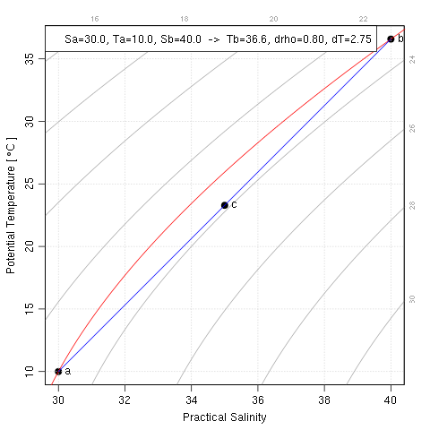

```python
%%R
library(oce)
Sa <- 30; Ta <- 10; Sb <- 40;
rho0 <- swRho(Sa, Ta, 0)
Tb <- uniroot(function(T) rho0-swRho(Sb,T,0), lower=0, upper=100)$root
Sc <- (Sa + Sb) /2; Tc <- (Ta + Tb) /2
drho <- swRho(Sc, Tc, 0) - rho0
dT <- drho / rho0 / swAlpha(Sc, Tc, 0)
plotTS(as.ctd(c(Sa, Sb, Sc), c(Ta, Tb, Tc), 0), pch=20, cex=2)
drawIsopycnals(levels=rho0, col="red", cex=0)
segments(Sa, Ta, Sb, Tb, col="blue")
text(Sb, Tb, "b", pos=4); text(Sa, Ta, "a", pos=4); text(Sc, Tc, "c", pos=4)
legend("topleft",legend=sprintf("Sa=%.1f, Ta=%.1f, Sb=%.1f  ->  Tb=%.1f, drho=%.2f, dT=%.2f",Sa, Ta, Sb, Tb, drho, dT),bg="white")
```